# Practical Machine Learning

Qian Zhang

Saturday, November 22, 2014

**Abstract**

The purpose of this project is to predict the manner in which participants did the barbell lifts exercise by using data from accelerometers on their belt, forearm, arm, and dumbell. The outcome is how well they did the physical acitivity, that is, whether participants did the exercise correctly or incorrectly. I use the random forest method for this course project.

**Data Preprocessing**

```r
library(caret)
library(randomForest)
training <- read.csv("pml-training.csv", header=T, sep=, na.strings=c("", "NA", "#DIV/0!"))
testing <- read.csv("pml-testing.csv", header=T, sep=, na.strings=c("", "NA", "#DIV/0!"))
```

Second, remove the first seven column, and then remove columns with all NAs and zeros.

```r
training <- training[,-c(1,2,3,4,5,6,7)]
testing <- testing[,-c(1,2,3,4,5,6,7)]
NAcols <- as.vector(sapply(training[,1:152], function(x) {length(which(is.na(x)!=0))}))
training <- training[,!NAcols]
testing <- testing[,!NAcols]
```

**Training with Random Forests**

In this stage, The training data is splitted to a training set and testing set. 60% of the training data is in the training set and 40% is in the testing set.

```r
inTrain <- createDataPartition(training$classe, p=.60)[[1]]
training.inTrain <- training[inTrain,]
testing.inTrain <- training[-inTrain,]
```

Then I will train the data with random forests.

```r
fitRF <- randomForest(training.inTrain$classe ~., data = training.inTrain, importance=T)
```

Some statistics on the results.

```r
summary(fitRF)
```

```
##                 Length Class  Mode
## call                4  -none- call
## type                1  -none- character
## predicted       11776  factor numeric
## err.rate         3000  -none- numeric
## confusion          30  -none- numeric
## votes           58880  matrix numeric
## oob.times       11776  -none- numeric
## classes             5  -none- character
## importance        364  -none- numeric
## importanceSD      312  -none- numeric
## localImportance     0  -none- NULL
## proximity           0  -none- NULL
## ntree               1  -none- numeric
## mtry                1  -none- numeric
## forest             14  -none- list
## y               11776  factor numeric
## test                0  -none- NULL
## inbag               0  -none- NULL
## terms               3  terms  call
```

```r
confusionMatrix(predict(fitRF, testing.inTrain), testing.inTrain$classe)
```

```
## Confusion Matrix and Statistics
##
##           Reference
## Prediction    A    B    C    D    E
##          A 2228   11    0    0    0
##          B    4 1503    5    0    0
##          C    0    4 1359   23    0
##          D    0    0    4 1261    7
##          E    0    0    0    2 1435
##
## Overall Statistics
##
##                Accuracy : 0.9924
##                  95% CI : (0.9902, 0.9942)
##     No Information Rate : 0.2845
##     P-Value [Acc > NIR] : < 2.2e-16
##
##                   Kappa : 0.9903
##  Mcnemar's Test P-Value : NA
##
## Statistics by Class:
##
##                      Class: A Class: B Class: C Class: D Class: E
## Sensitivity            0.9982   0.9901   0.9934   0.9806   0.9951
## Specificity            0.9980   0.9986   0.9958   0.9983   0.9997
## Pos Pred Value         0.9951   0.9940   0.9805   0.9914   0.9986
## Neg Pred Value         0.9993   0.9976   0.9986   0.9962   0.9989
## Prevalence             0.2845   0.1935   0.1744   0.1639   0.1838
## Detection Rate         0.2840   0.1916   0.1732   0.1607   0.1829
## Detection Prevalence   0.2854   0.1927   0.1767   0.1621   0.1832
## Balanced Accuracy      0.9981   0.9943   0.9946   0.9894   0.9974
```

The following plot shows the training error vs. the number of trees.

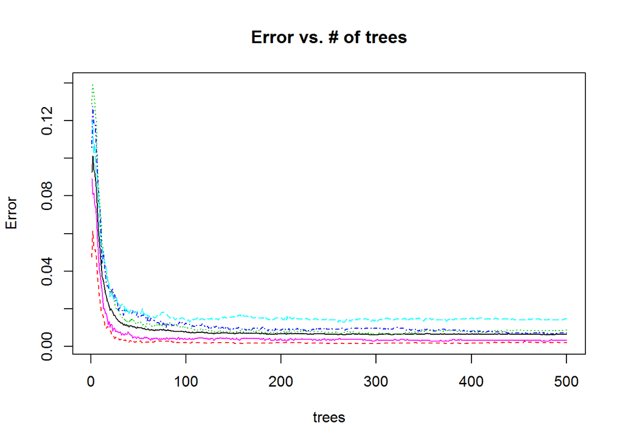

```r
plot(fitRF, main="Error vs. # of trees")
```

**Final Prediction**

This is the final random forests model and the prediction.

```r
finalRF <- randomForest(training$classe ~., data = training, importance=T, na.action = na.omit)
predict(finalRF, newdata=testing)
```

```
##  1  2  3  4  5  6  7  8  9 10 11 12 13 14 15 16 17 18 19 20
##  B  A  B  A  A  E  D  B  A  A  B  C  B  A  E  E  A  B  B  B
## Levels: A B C D E
```